# Лабораторная 3. Декомпозиция

```r
set.seed(20260930)
retail_id <- sample(aus_retail$`Series ID`, 1)
myseries <- aus_retail |> filter(`Series ID` == retail_id)
```

## 1. ВВП на душу населения

[figure not shown]

```r
gdp_pc <- global_economy |>
  mutate(gdp_pc = GDP / Population) |>
  select(Country, Year, gdp_pc)
autoplot(gdp_pc, gdp_pc) +
  labs(title = "ВВП на душу населения", y = "ВВП / человек")
```

```r
gdp_pc |>
  as_tibble() |>
  filter(!is.na(gdp_pc)) |>
  slice_max(gdp_pc, n = 1)
```

```
## # A tibble: 1 × 3
##   Country  Year  gdp_pc
##   <fct>   <dbl>   <dbl>
## 1 Monaco   2014 185153.
```

```r
top_now <- gdp_pc |>
  as_tibble() |>
  group_by(Country) |>
  slice_max(Year, n = 1) |>
  ungroup() |>
  slice_max(gdp_pc, n = 5)
top_now
```

```
## # A tibble: 5 × 3
##   Country           Year  gdp_pc
##   <fct>            <dbl>   <dbl>
## 1 Luxembourg        2017 104103.
## 2 Macao SAR, China  2017  80893.
## 3 Switzerland       2017  80190.
## 4 Norway            2017  75505.
## 5 Iceland           2017  70057.
```

Лидер по уровню меняется: долго вверху Монако, Лихтенштейн и нефтедобывающие экономики, к концу выборки в пятёрке остаются небольшие богатые страны. У большинства стран ряд растёт, но разрыв не схлопывается.

## 2. Когда нужно преобразование

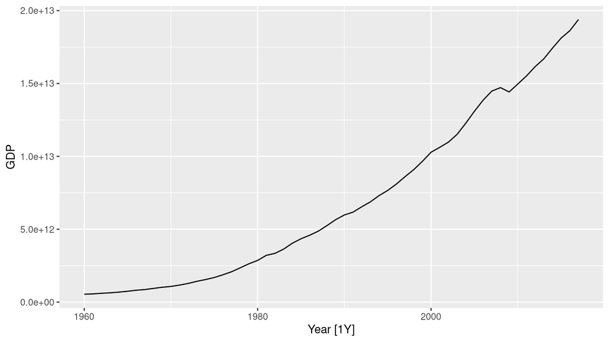

```r
us_gdp <- global_economy |> filter(Country == "United States")
autoplot(us_gdp, GDP)
```

```r
lambda_us <- us_gdp |> features(GDP, guerrero) |> pull(lambda_guerrero)
lambda_us
```

```
## [1] 0.2819443
```

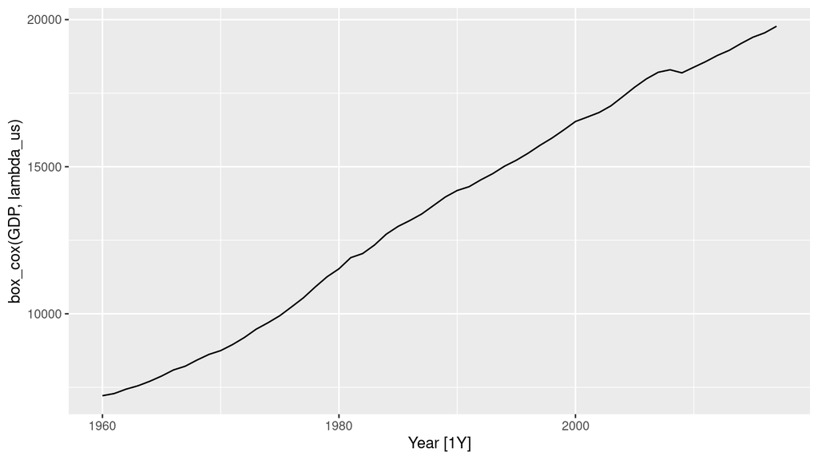

```r
autoplot(us_gdp, box_cox(GDP, lambda_us))
```

ВВП США растёт с увеличивающимся размахом. Box–Cox (λ около 0.3) делает колебания более ровными; логарифм тоже подходит.

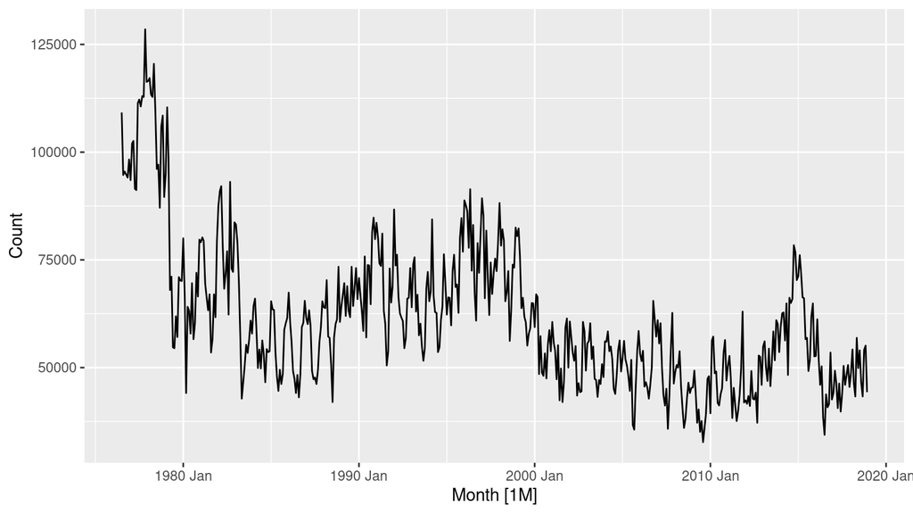

```r
bulls <- aus_livestock |>
  filter(Animal == "Bulls, bullocks and steers", State == "Victoria")
autoplot(bulls, Count)
```

```r
lambda_bulls <- bulls |> features(Count, guerrero) |> pull(lambda_guerrero)
lambda_bulls
```

```
## [1] -0.04461887
```

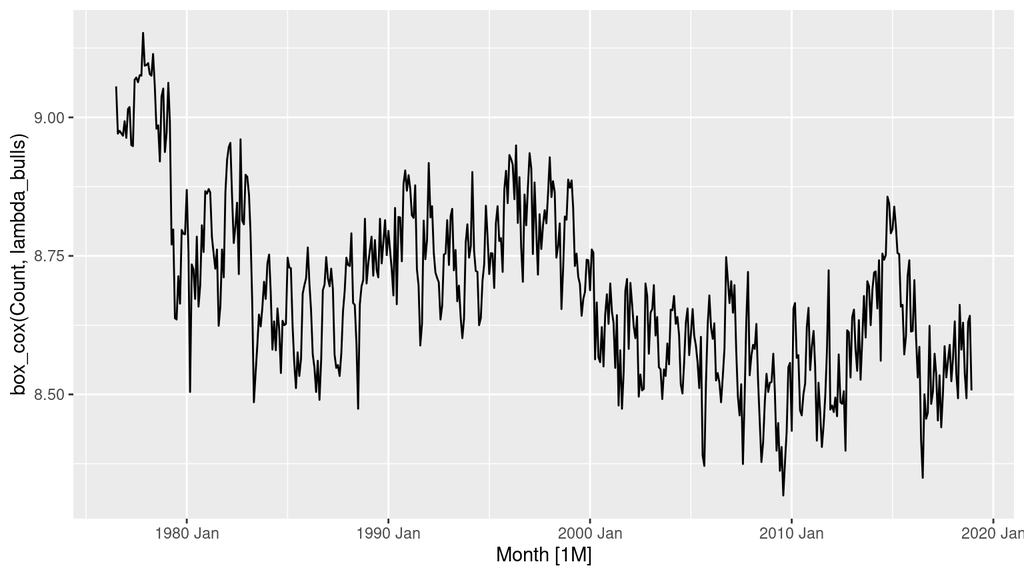

```r
autoplot(bulls, box_cox(Count, lambda_bulls))
```

У забоя размах меняется умеренно. Преобразование слегка выравнивает дисперсию, форма ряда остаётся той же.

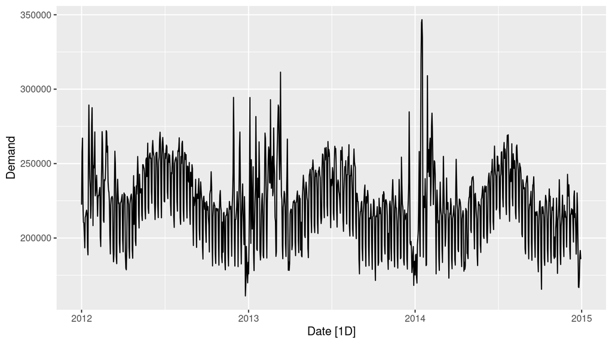

```r
vic_day <- vic_elec |>
  index_by(Date) |>
  summarise(Demand = sum(Demand))
autoplot(vic_day, Demand)
```

Суточный спрос уже довольно стабилен по размаху, сильное преобразование не нужно: виден сезон и недельный ритм, а не веер.

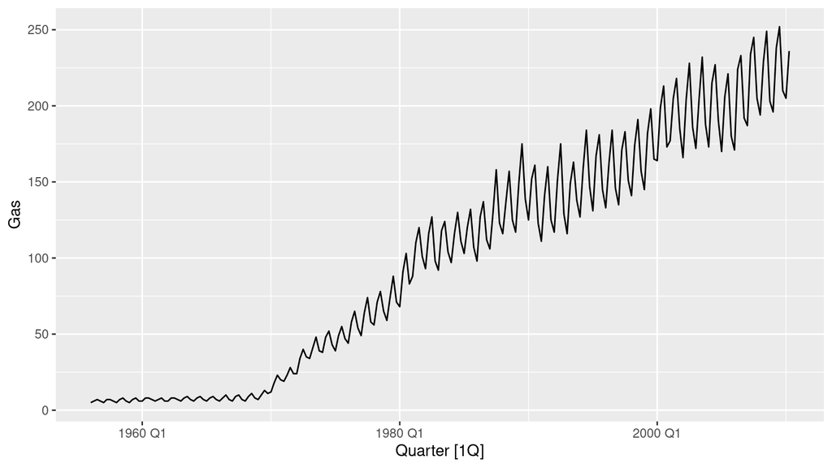

```r
autoplot(aus_production, Gas)
```

```r
lambda_gas <- aus_production |> features(Gas, guerrero) |> pull(lambda_guerrero)
lambda_gas
```

```
## [1] 0.1095171
```

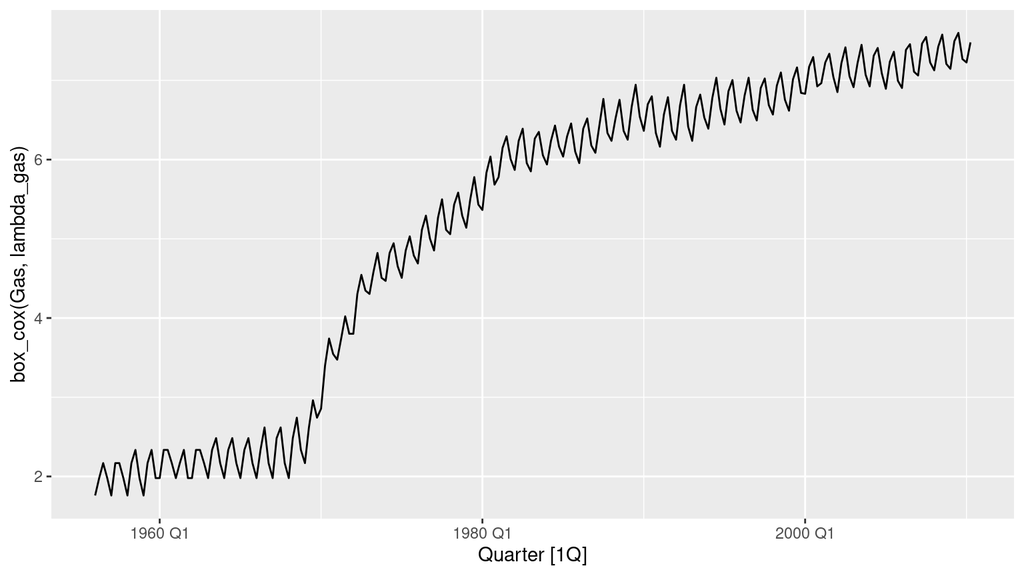

```r
autoplot(aus_production, box_cox(Gas, lambda_gas))
```

У газа сезонная амплитуда растёт вместе с уровнем. λ заметно меньше 1, после преобразования сезонные зубцы ближе по высоте.

## 3. Почему Box–Cox бесполезен для canadian_gas

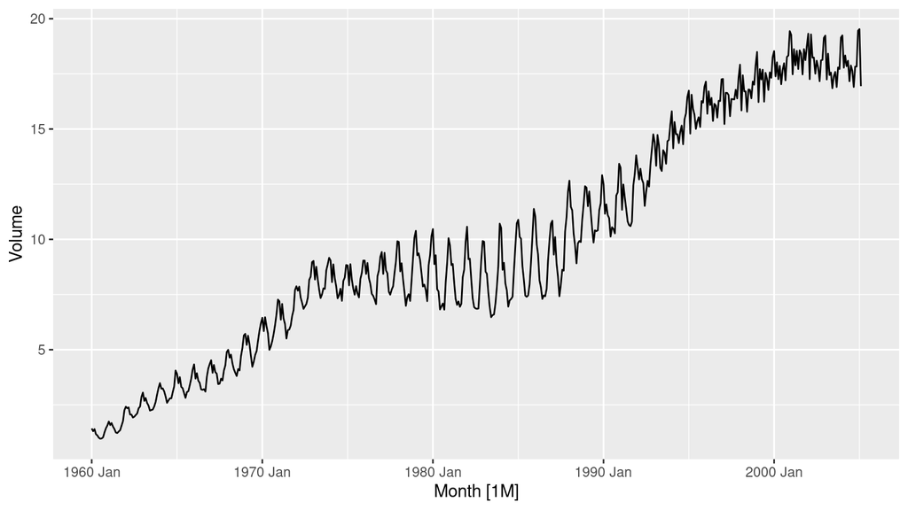

```r
autoplot(canadian_gas, Volume)
```

```r
lambda_cg <- canadian_gas |> features(Volume, guerrero) |> pull(lambda_guerrero)
lambda_cg
```

```
## [1] 0.5767648
```

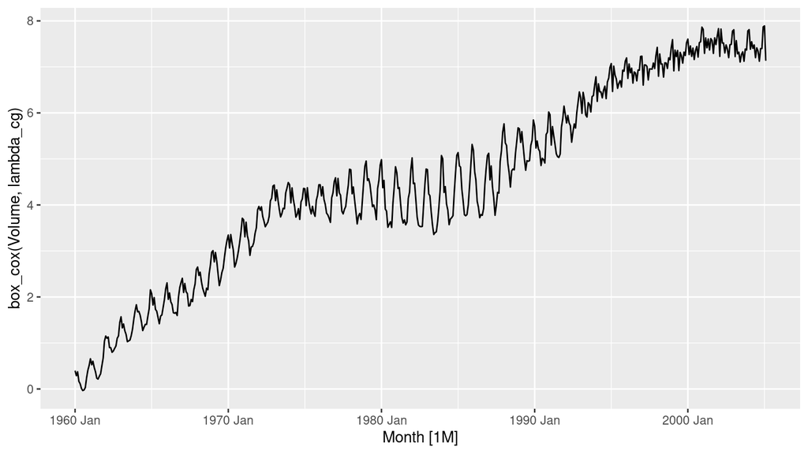

```r
autoplot(canadian_gas, box_cox(Volume, lambda_cg))
```

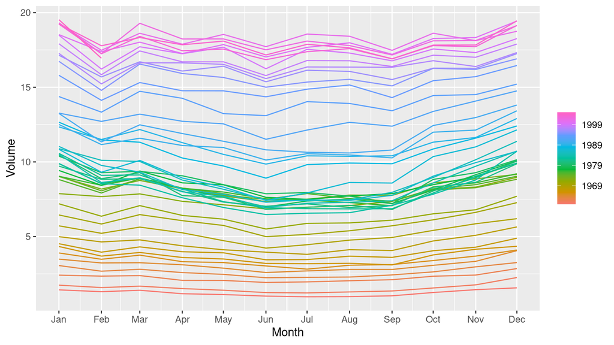

```r
gg_season(canadian_gas, Volume)
```

Дисперсия и так не раздувается пропорционально уровню. Мешает другое: форма сезона со временем меняется. Степенное преобразование одинаково растягивает все даты и эту смену формы не убирает.

## 4. Box–Cox для розничного ряда

```r
lambda_retail <- myseries |> features(Turnover, guerrero) |> pull(lambda_guerrero)
lambda_retail
```

```
## [1] 0.1895908
```

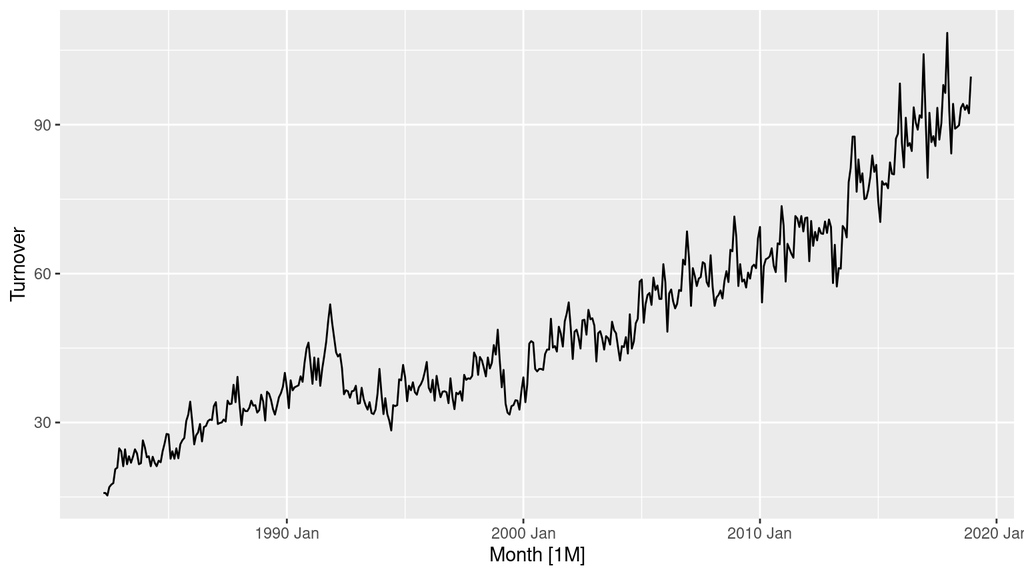

```r
autoplot(myseries, Turnover)
```

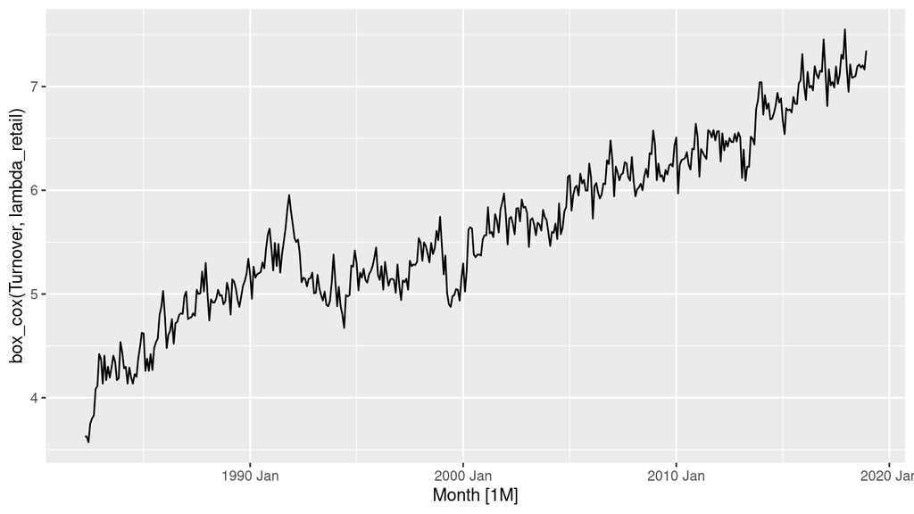

```r
autoplot(myseries, box_cox(Turnover, lambda_retail))
```

Беру λ Гьерреро. Она меньше 1: сезонная амплитуда растёт, логарифм или степень около нуля выравнивает её.

## 5. Ещё три ряда

```
## [1] 0.9264636
```

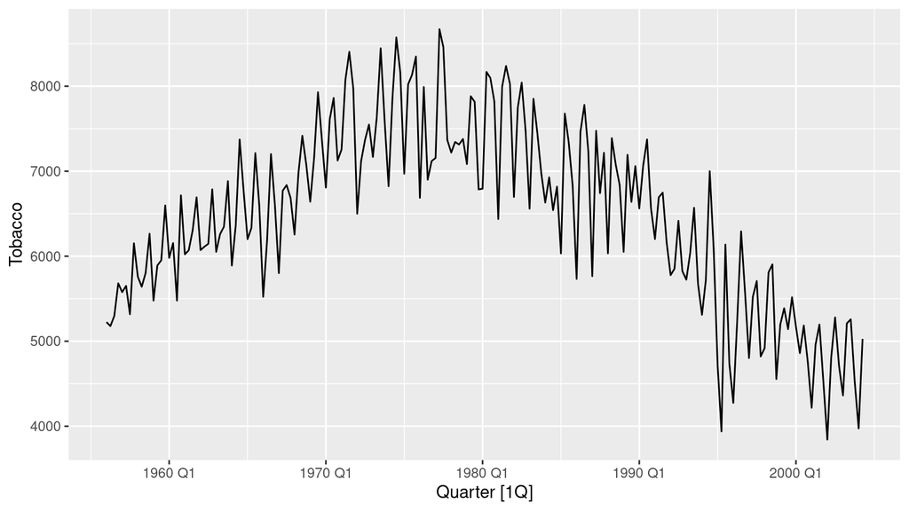

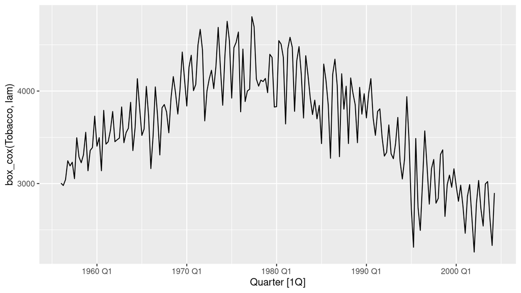

```r
show_lambda <- function(data, y) {
  y <- enquo(y)
  lam <- data |> features(!!y, guerrero) |> pull(lambda_guerrero)
  print(lam)
  print(autoplot(data, !!y))
  print(autoplot(data, box_cox(!!y, lam)))
  invisible(lam)
}
show_lambda(aus_production |> select(Tobacco) |> filter(!is.na(Tobacco)), Tobacco)
```

```r
economy <- ansett |> filter(Airports == "MEL-SYD", Class == "Economy")
show_lambda(economy, Passengers)
```

```
## [1] 1.999927
```

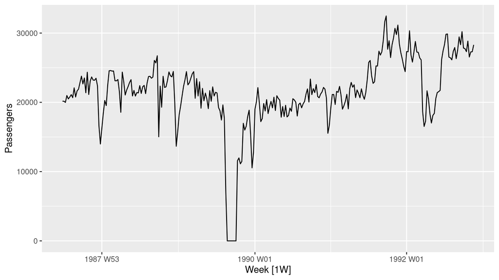

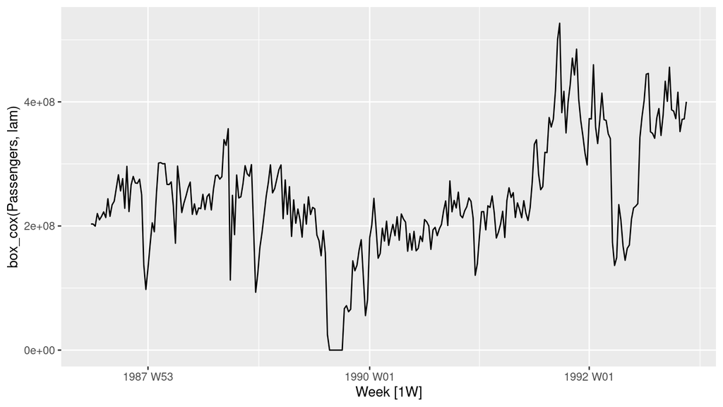

```r
south <- pedestrian |>
  filter(Sensor == "Southern Cross Station") |>
  index_by(Date) |>
  summarise(Count = sum(Count))
show_lambda(south, Count)
```

```
## [1] 0.2726316
```

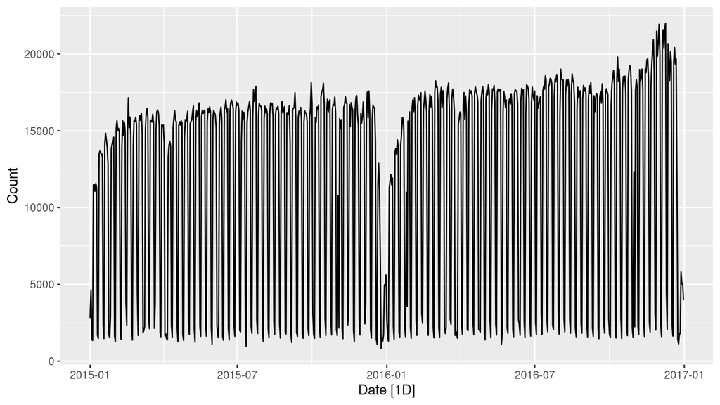

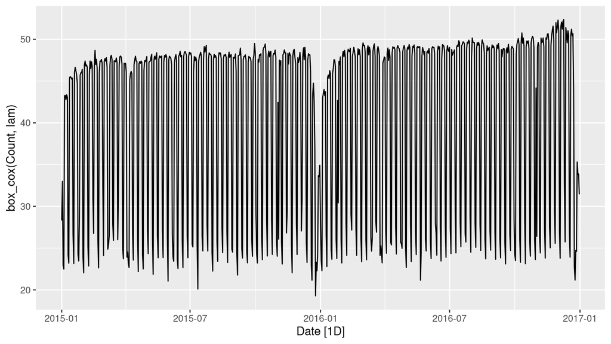

## 6. Скользящее среднее $3 \times 5$

Сначала окно 5 с равными весами $1/5$, затем окно 3 с весами $1/3$. Свёртка даёт окно длины $5+3-1=7$:

```r
conv <- function(a, b) {
  out <- numeric(length(a) + length(b) - 1)
  for (i in seq_along(a)) {
    out[i:(i + length(b) - 1)] <- out[i:(i + length(b) - 1)] + a[i] * b
  }
  out
}
w <- conv(rep(1 / 5, 5), rep(1 / 3, 3))
round(w, 3)
```

```
## [1] 0.067 0.133 0.200 0.200 0.200 0.133 0.067
```

Веса 0.067, 0.133, 0.200, 0.200, 0.200, 0.133, 0.067. Крайние точки попадают только в одно из окон длины 5, соседние — в два, центральные — в три, отсюда доли $1/15$, $2/15$, $3/15$.

```r
gas <- aus_production |> select(Gas)
one <- gas$Gas
ma5 <- stats::filter(one, rep(1 / 5, 5), sides = 2)
ma3of5 <- as.numeric(stats::filter(ma5, rep(1 / 3, 3), sides = 2))
wma7 <- as.numeric(stats::filter(one, w, sides = 2))
max(abs(ma3of5 - wma7), na.rm = TRUE)
```

```
## [1] 5.684342e-14
```

Расхождение на уровне машинного нуля: два способа совпадают.

## 7. Газ, последние пять лет

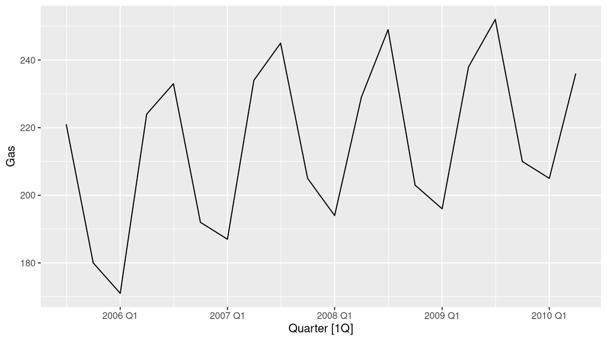

```r
gas5 <- aus_production |>
  select(Gas) |>
  slice_tail(n = 5 * 4)
autoplot(gas5, Gas)
```

Виден сезонный пик внутри года и слабый тренд на коротком окне.

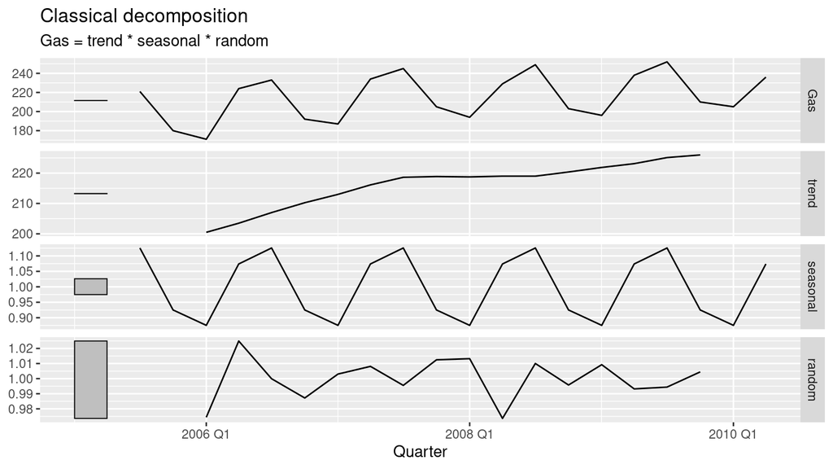

```r
fit_classical <- gas5 |>
  model(classical_decomposition(Gas, type = "multiplicative"))
components(fit_classical) |> autoplot()
```

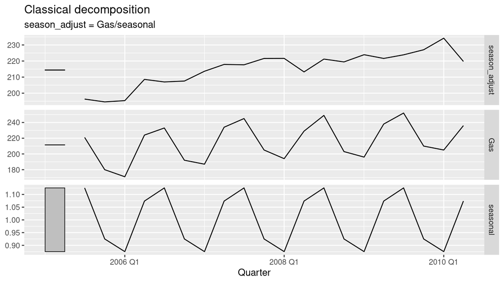

```r
components(fit_classical) |>
  autoplot(season_adjust)
```

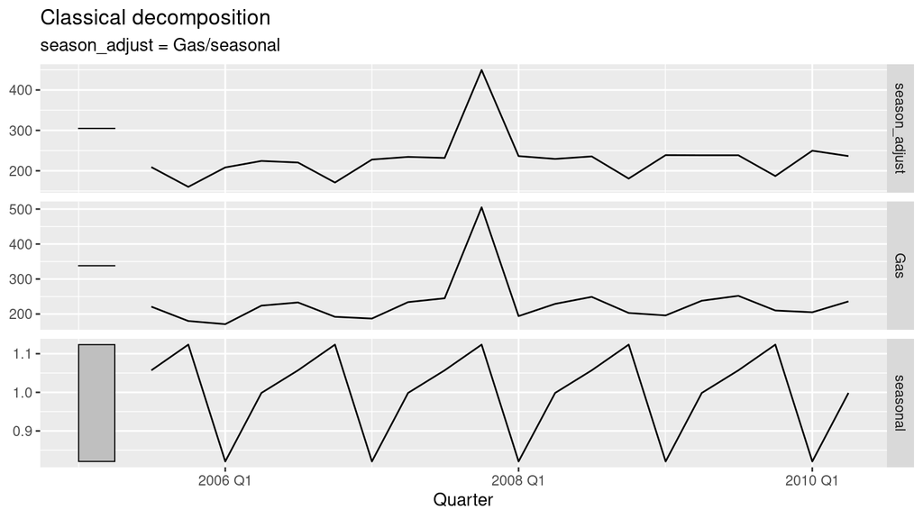

```r
gas_mid <- gas5 |>
  mutate(Gas = if_else(row_number() == n() %/% 2, Gas + 300, Gas))
gas_end <- gas5 |>
  mutate(Gas = if_else(row_number() == n(), Gas + 300, Gas))
adj <- function(data) {
  data |>
    model(classical_decomposition(Gas, type = "multiplicative")) |>
    components() |>
    autoplot(season_adjust)
}
adj(gas_mid)
```

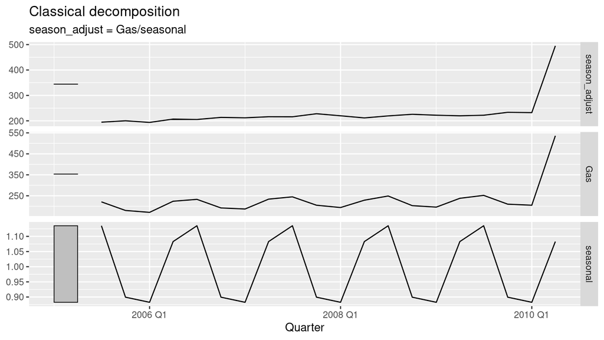

```r
adj(gas_end)
```

## 8. X-11 для розницы

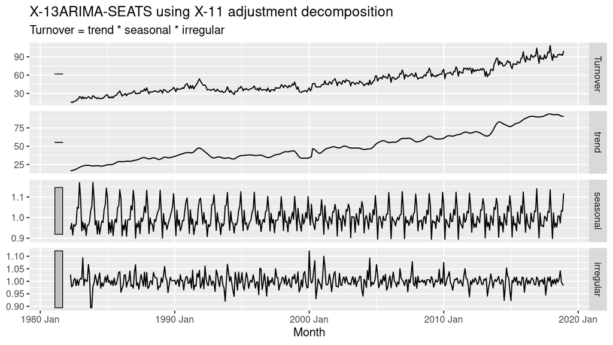

```r
x11_fit <- myseries |>
  model(x11 = X_13ARIMA_SEATS(Turnover ~ x11()))
components(x11_fit) |> autoplot()
```

X-11 отделяет тренд, сезон и остаток. В остатке видны отдельные месяцы, которые на исходном графике терялись на фоне растущего сезона: это кандидаты в выбросы. Сезон устойчивый, тренд гладкий.

## 9. Рабочая сила Австралии, рис. 3.19–3.20

На рисунках книги тренд — самая крупная компонента: численность рабочей силы за 1978–1995 выросла на миллионы, внутри года сезон — это десятки тысяч и он почти не меняет форму. Остаток ещё меньше. Рецессия 1991/1992 видна как провал тренда и полоса отрицательных остатков, а не как слом сезонной фигуры. Масштаб осей здесь главный: сезон нельзя читать как «большое» движение только потому, что его график заполняет панель.

## 10. Меняющаяся сезонность canadian_gas

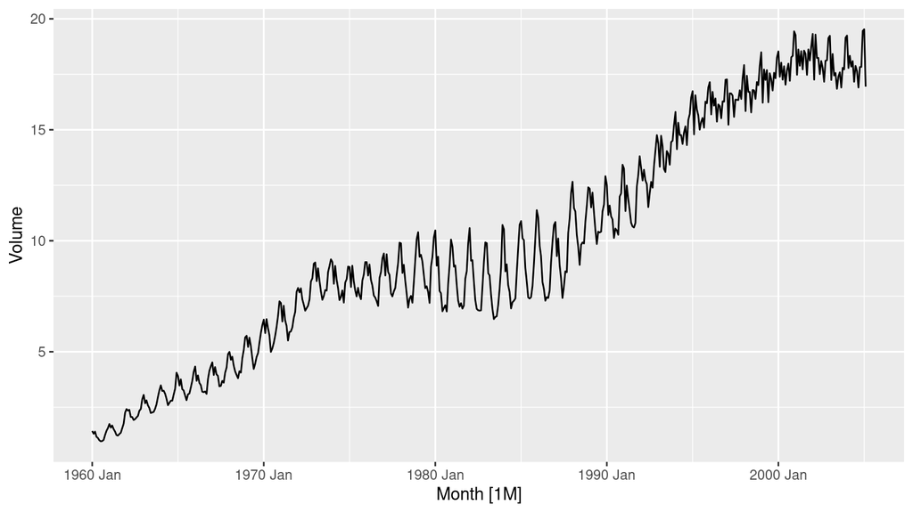

```r
autoplot(canadian_gas, Volume)
```

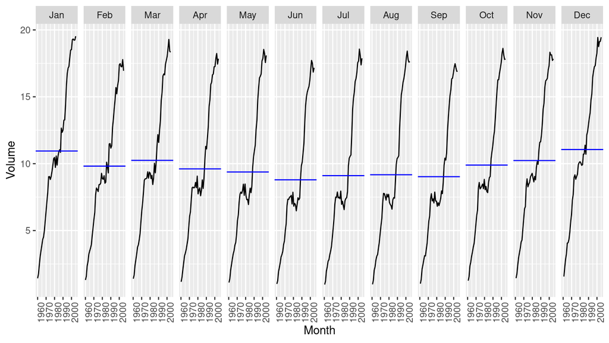

```r
gg_subseries(canadian_gas, Volume)
```

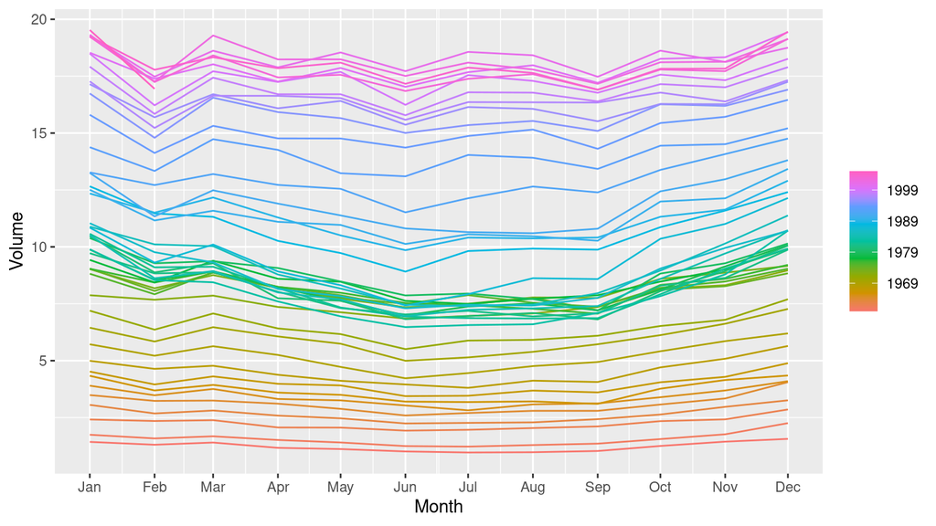

```r
gg_season(canadian_gas, Volume)
```

Зимний пик со временем сдвигается и меняет высоту относительно лета. Это не одна и та же сезонная кривая.

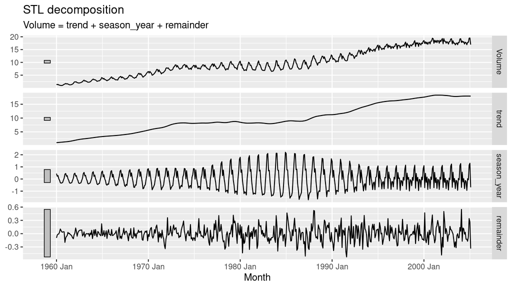

```r
stl_fit <- canadian_gas |>
  model(STL(Volume ~ season(window = 7)))
stl_cmp <- components(stl_fit)
autoplot(stl_cmp)
```